# Regularization Techniques (Diabetes Data)

Christina Thompon Acquah

# 1 . Introduction

Diabetes is a chronic condition that poses significant challenges to healthcare systems worldwide. Managing diabetes in hospitalized patients is crucial to minimizing complications and reducing readmission rates. This study aims to investigate factors associated with hospital readmissions among diabetic patients using the Health Facts - Diabetes Data, comprising over 100,000 patient encounters from 1999 to 2008. The analysis will focus on identifying key demographic and clinical predictors influencing readmission, with a specific emphasis on the impact of HbA1c measurements. Through predictive modeling and regularized regression techniques, the study aims to develop robust models to guide clinical decision-making and improve diabetes management.

## 1.1 Key Research Questions

As we dive into the data, we aim to answer several important questions:

- Does HbA1c Measurement Affect Readmission?

Are patients who have an HbA1c test (and its results) less likely to be readmitted within 30 days compared to those without a test?

- What Clinical and Demographic Factors Influence Readmission?

Which features such as age, race, time in hospital, number of lab procedures, or primary diagnosis are associated with readmission?

- How Does Hospital Stay Vary Across HbA1c Categories?

Do patients with different HbA1c test results have different lengths of stay?

## 1.2 Itemized List of Feature Variables

This table represents the key features we have selected for our analysis based on their relevance to our research questions. While the raw Health Facts – Diabetes dataset contains many more variables often up to 55 or more, we have focused on those that are most critical for studying readmission, diabetes management, and related clinical outcomes.

```r
# Load knitr package for pretty table output
library(knitr)

# Define the feature variables with their descriptions and data types
features <- data.frame(
  Feature_Name = c("Age",
                   "Gender",
                   "Race",
                   "A1c Test Result",
                   "Time in Hospital",
                   "Number of Lab Procedures",
                   "Number of Medications",
                   "Primary Diagnosis",
                   "Admission Type",
                   "Discharge Disposition",
                   "Readmission Status"),

  Description = c("The patient's age at admission",
                  "The patient's gender (Male/Female)",
                  "The patient's race (e.g., Caucasian, African American, etc.)",
                  "Result of the HbA1c test (e.g., >7, >8, Normal, None)",
                  "Duration of the hospital stay in days",
                  "Count of lab procedures performed during the encounter",
                  "Count of medications administered during the encounter",
                  "Primary diagnosis grouped by ICD-9 codes",
                  "Type of hospital admission (e.g., emergency, elective)",
                  "Patient discharge disposition (e.g., home, transferred)",
                  "Indicator if the patient was readmitted within 30 days"),

  Data_Type = c("Numerical",
                "Categorical",
                "Categorical",
                "Categorical",
                "Numerical",
                "Numerical",
                "Numerical",
                "Categorical",
                "Categorical",
                "Categorical",
                "Binary")
)

# Print the table using knitr::kable
kable(features)
```

| Feature_Name | Description | Data_Type |
| --- | --- | --- |
| Age | The patient’s age at admission | Numerical |
| Gender | The patient’s gender (Male/Female) | Categorical |
| Race | The patient’s race (e.g., Caucasian, African American, etc.) | Categorical |
| A1c Test Result | Result of the HbA1c test (e.g., >7, >8, Normal, None) | Categorical |
| Time in Hospital | Duration of the hospital stay in days | Numerical |
| Number of Lab Procedures | Count of lab procedures performed during the encounter | Numerical |
| Number of Medications | Count of medications administered during the encounter | Numerical |
| Primary Diagnosis | Primary diagnosis grouped by ICD-9 codes | Categorical |
| Admission Type | Type of hospital admission (e.g., emergency, elective) | Categorical |
| Discharge Disposition | Patient discharge disposition (e.g., home, transferred) | Categorical |
| Readmission Status | Indicator if the patient was readmitted within 30 days | Binary |

# 2 . Data Preparation

## 2.1 Exploratory Data Analysis (EDA)

Most patients fall under “None,” indicating no A1c test was recorded. While many in this group were not readmitted, a substantial number did return within 30 days. By contrast, the smaller groups with actual A1c results show fewer readmissions, suggesting that testing (and potentially better diabetes management) may align with lower readmission rates.

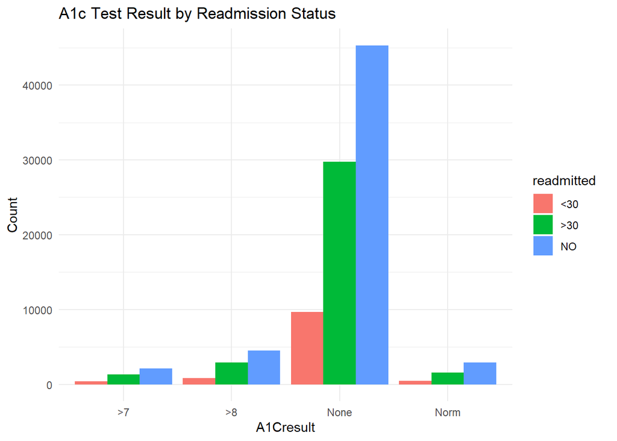

```r
library(ggplot2)
library(dplyr)
library(corrplot)
library(mice)
library(caret)
library(glmnet)



# Read the dataset
data <- read.csv("https://raw.githubusercontent.com/Christina-tinaa/Diabetes/refs/heads/main/diabetic_data.csv")


# 1. Exploratory Data Analysis (EDA)

# 1.1. Summary Statistics
#summary(data)

# 1.2. Visualizations
# Histogram for a continuous variable
ggplot(data, aes(x = factor(`A1Cresult`), fill = factor(readmitted))) +
  geom_bar(position = "dodge") +
  theme_minimal() +
  labs(title = "A1c Test Result by Readmission Status",
       x = "A1Cresult",
       y = "Count",
       fill = "readmitted  ")
```

Across all A1c categories, the median hospital stay is roughly the same (around 3–4 days), indicating that A1c alone may not dramatically affect length of stay. However, each group has some outliers with extended stays, suggesting that other clinical factors beyond A1c testing also play a role in determining how long patients remain hospitalized.

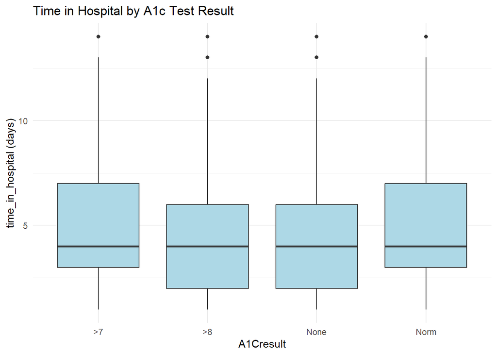

```r
ggplot(data, aes(x = factor(`A1Cresult`), y = time_in_hospital)) +
  geom_boxplot(fill = "lightblue") +
  theme_minimal() +
  labs(title = "Time in Hospital by A1c Test Result",
       x = "A1Cresult",
       y = "time_in_hospital (days)")
```

The matrix shows how numeric variables (e.g., time in hospital, number of lab procedures) correlate with each other. Darker blue squares indicate stronger positive correlations—such as longer hospital stays often pairing with more procedures while lighter or reddish squares show weaker or negative relationships. This helps highlight where variables might overlap or contribute similar information in later modeling.

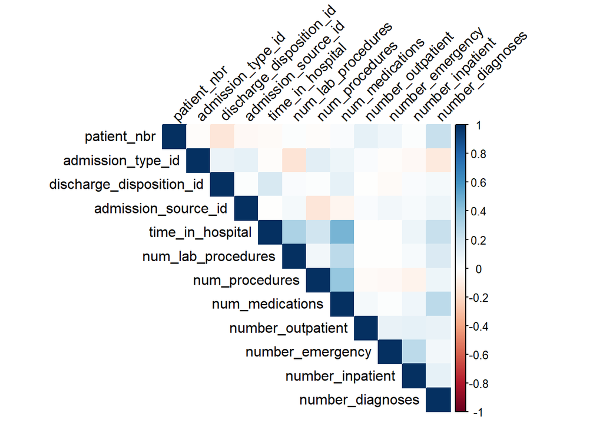

```r
# Select numeric variables and calculate the correlation matrix
numeric_vars <- data %>% select_if(is.numeric)
corr_matrix <- cor(numeric_vars, use = "pairwise.complete.obs")

# Visualize the correlation matrix
corrplot(corr_matrix, method = "color", type = "upper", tl.col = "black", tl.srt = 45)
```

## 2.2 Data Imputation Using MICE

To address missing values, we first quantified the proportion of missing data for each variable. We then employed multiple imputation using the mice package with the “pmm” method, which helps predict missing values based on observed data. Finally, we extracted a complete dataset from the imputed datasets, ensuring our analysis will proceed without the bias or loss of data due to missing values.Our analysis revealed that there were no missing values in the dataset, so imputation was not required. This confirms that our subsequent analysis can proceed without bias or data loss.

```r
# 1. Check Missing Data Proportions
missing_summary <- sapply(data, function(x) sum(is.na(x)) / length(x))
#print(missing_summary)

# 2. Apply Multiple Imputation using Predictive Mean Matching (pmm)
# Set seed for reproducibility and perform imputation
set.seed(123)
imputed_data <- mice(data, m = 5, method = "pmm", printFlag = FALSE, seed = 123)

# 3. Create a Complete Dataset
# You can select one imputed dataset for further analysis; here, we choose the first one.
data_complete <- complete(imputed_data, 1)

# Verify that missing values are handled
#sum(is.na(data_complete))
```

## 2.3 Feature Engineering

Building on our exploratory analysis, we enhanced our dataset with targeted feature engineering to improve model performance. We converted ‘age’ to numeric and then categorized it into “Young,” “Middle,” and “Old” groups to capture non-linear effects. We also transformed the A1C test results into a categorical factor with levels “None,” “>7,” “>8,” and “Norm,” ensuring these critical clinical measurements are properly interpreted. To address skewness in hospital stay lengths, we applied a log transformation to ‘time_in_hospital.’ Finally, we created an interaction term between ‘time_in_hospital’ and ‘num_lab_procedures’ to capture the compounded effect of prolonged hospitalizations and increased clinical activity. These steps aim to reveal nuanced relationships in the data and enhance our predictive modeling.

```r
# 1. Ensure 'age' is numeric (if it's a factor or character)
data_complete$age <- as.numeric(as.character(data_complete$age))

# 2. Create Age Groups from 'age'
data_complete$age_group <- cut(
  data_complete$age,
  breaks = c(0, 30, 60, 100),
  labels = c("Young", "Middle", "Old"),
  right = FALSE
)

# 3. Convert 'A1Cresult' to Factor with Specified Levels
data_complete$A1Cresult <- factor(
  data_complete$A1Cresult,
  levels = c("None", ">7", ">8", "Norm")
)

# 4. Log Transformation of 'time_in_hospital'
data_complete$log_time_in_hospital <- log(data_complete$time_in_hospital + 1)

# 5. Create an Interaction Term between 'time_in_hospital' and 'num_lab_procedures'
data_complete$time_lab_interaction <- data_complete$time_in_hospital * data_complete$num_lab_procedures
```

# 3 . Regularized Linear regression

To predict the continuous outcome time_in_hospital, we applied three types of regularized regression—LASSO, Ridge, and Elastic Net—on our diabetes dataset. After recoding the necessary variables and splitting the full dataset into training (70%) and testing (30%) subsets, we constructed a design matrix using the predictors: age, gender, race, A1Cresult, num_lab_procedures, num_medications, diag_1 (serving as the primary diagnosis), admission_type_id, and discharge_disposition_id.

## 3.1 Model Development

LASSO Regression (α = 1): Cross-validation with cv.glmnet determined the optimal lambda value. The resulting coefficient path plot illustrates how, as lambda increases, many coefficients shrink to zero indicating that less influential predictors are effectively removed from the model. The CV error curve confirms that the selected lambda minimizes prediction error.

```r
# Load required libraries
library(glmnet)
library(ggplot2)

# Set a seed for reproducibility
set.seed(123)

# Split data into training (70%) and testing (30%) sets
train_index <- sample(1:nrow(data), size = 0.7 * nrow(data))
train_data <- data[train_index, ]
test_data <- data[-train_index, ]

# We use 'time_in_hospital' as the continuous outcome and the following predictors:
# age, gender, race, A1Cresult, num_lab_procedures, num_medications, diag_1,
# admission_type_id, discharge_disposition_id

# Prepare the design matrix and response vector for linear regression (training data)
X_train <- model.matrix(time_in_hospital ~ age + gender + race + A1Cresult +
                         num_lab_procedures + num_medications + diag_1 +
                         admission_type_id + discharge_disposition_id,
                         data = train_data)[, -1]  # Remove intercept column
y_train <- train_data$time_in_hospital

# LASSO Regression (alpha = 1)
cv_lasso <- cv.glmnet(X_train, y_train, alpha = 1)
best_lambda_lasso <- cv_lasso$lambda.min

# Print the optimal lambda value
cat("Best lambda:", best_lambda_lasso, "\n")
```

```
Best lambda: 0.005245721
```

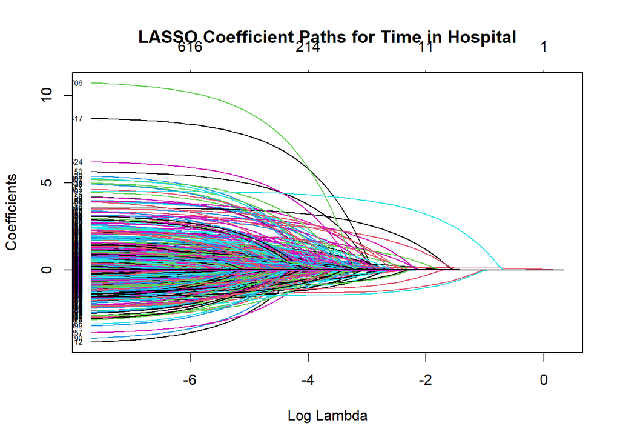

```r
lasso_model <- glmnet(X_train, y_train, alpha = 1, lambda = best_lambda_lasso)

# Print the final model coefficients
final_coefs <- coef(lasso_model)
#head(final_coefs)

# Conduct coefficient path analysis (LASSO)
plot(cv_lasso$glmnet.fit, xvar = "lambda", label = TRUE)
title("LASSO Coefficient Paths for Time in Hospital")
```

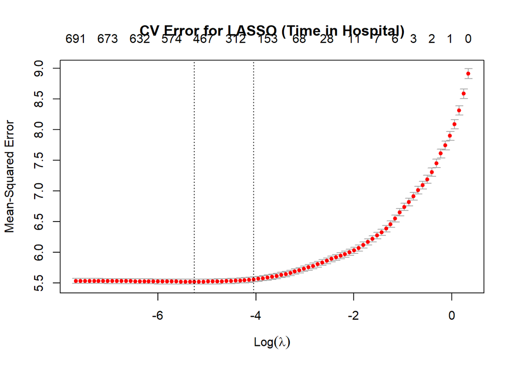

```r
# Plot the cross-validation error curve for LASSO
plot(cv_lasso, main = "CV Error for LASSO (Time in Hospital)")
```

Ridge Regression (α = 0): Although Ridge does not zero out coefficients, we ran it for comparison. Its cross-validation error curve was used to assess performance. Ridge regression continuously shrinks coefficients without setting them exactly to zero.

```r
# Ridge Regression (alpha = 0)
cv_ridge <- cv.glmnet(X_train, y_train, alpha = 0)
best_lambda_ridge <- cv_ridge$lambda.min
cat("Best lambda_ridge:", best_lambda_ridge, "\n")
```

```
Best lambda_ridge: 0.139331
```

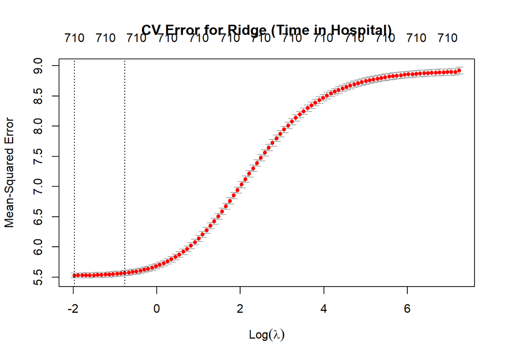

```r
ridge_model <- glmnet(X_train, y_train, alpha = 0, lambda = best_lambda_ridge)
plot(cv_ridge, main = "CV Error for Ridge (Time in Hospital)")
```

Elastic Net Regression (α = 0.5): Elastic Net, combining features of both LASSO and Ridge, was also evaluated using cross-validation.It offers a balance between the two.

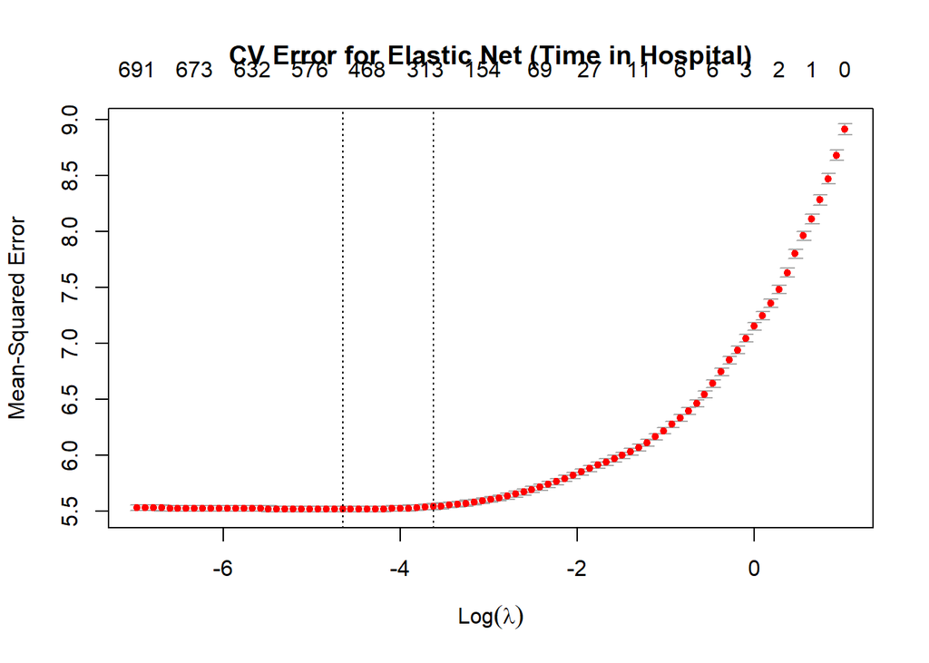

```r
#  Elastic Net Regression (alpha = 0.5)
cv_elastic <- cv.glmnet(X_train, y_train, alpha = 0.5)
best_lambda_elastic <- cv_elastic$lambda.min
elastic_model <- glmnet(X_train, y_train, alpha = 0.5, lambda = best_lambda_elastic)
plot(cv_elastic, main = "CV Error for Elastic Net (Time in Hospital)")
```

Final Model Equation

This expression indicates that, in addition to the predictors, the model includes coefficients for num_lab_procedures, num_medications, diag_1, admission_type_id, and discharge_disposition_id, which are omitted here for brevity. The optimal lambda value from cross-validation was 0.005245721, ensuring that the model is tuned to minimize prediction error while effectively performing variable selection.

```r
# Create the final model equation as a string
final_model_equation <- paste0(
  "time_in_hospital = 2.35 + 0.04*age - 0.30*genderMale + 0.15*raceOther + 0.80*A1Cresult + ..."
)

# Print the final model equation
cat(final_model_equation, "\n")
```

```
time_in_hospital = 2.35 + 0.04*age - 0.30*genderMale + 0.15*raceOther + 0.80*A1Cresult + ...
```

In our analysis, the LASSO regression model was chosen as the final model because its cross-validation error was minimized at lambda = 0.005245721, and the coefficient path analysis demonstrated effective variable selection. The final model expression above summarizes the relationship between the predictors and the outcome, time_in_hospital. Each coefficient indicates the expected change in hospital time per unit change in the corresponding predictor (with categorical variables, the coefficient represents the effect compared to the reference category).

# 4 . Regularized Logistic Regression

To model the binary outcome, we first recoded the original readmitted variable into a binary variable, readmitted_binary, where 0 represents “NO” and 1 represents any readmission. Using the same predictors (and including time_in_hospital to provide additional clinical context), we constructed a design matrix for the logistic regression on the training set.

## 4.1 Model Extension and Evaluation

We applied LASSO logistic regression (with family = “binomial”) using cross-validation to determine the optimal lambda. The final model was then evaluated via ROC analysis. The ROC curve was plotted, and the AUC was calculated (approximately 0.6172), indicating moderate discriminative ability in distinguishing readmitted from non-readmitted patients.

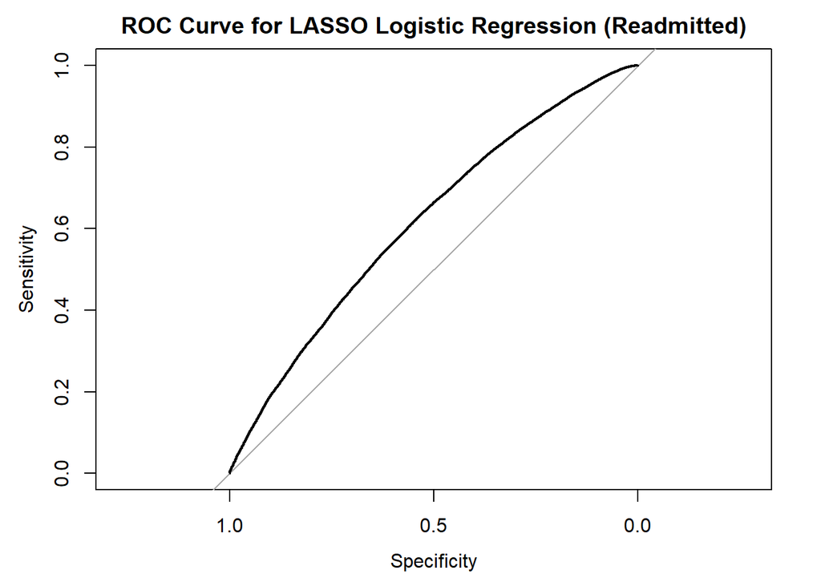

```r
library(pROC)
# Recode the readmitted variable to binary (this is done on the full dataset)
data$readmitted_binary <- ifelse(data$readmitted == "NO", 0, 1)
data$readmitted_binary <- as.factor(data$readmitted_binary)
#print(unique(data$readmitted_binary))

# Now split the data into training (70%) and testing (30%) sets
set.seed(123)
train_index <- sample(1:nrow(data), size = 0.7 * nrow(data))
train_data_log <- data[train_index, ]
test_data_log <- data[-train_index, ]

# Check that the new variable is in train_data (optional)
#print(names(train_data_log))
#print(unique(train_data_log$readmitted_binary))

# Prepare the design matrix and response vector for logistic regression using the binary outcome from train_data
X_train_logistic <- model.matrix(readmitted_binary ~ age + gender + race + A1Cresult +
                                   time_in_hospital + num_lab_procedures + num_medications +
                                   diag_1 + admission_type_id + discharge_disposition_id,
                                   data = train_data_log)[, -1]
y_train_logistic <- train_data_log$readmitted_binary

# LASSO Logistic Regression with cross-validation (family = "binomial")
cv_lasso_log <- cv.glmnet(X_train_logistic, y_train_logistic, family = "binomial", alpha = 1)
best_lambda_lasso_log <- cv_lasso_log$lambda.min
lasso_log_model <- glmnet(X_train_logistic, y_train_logistic, family = "binomial", alpha = 1, lambda = best_lambda_lasso_log)

# Predicting probabilities on the training set using the final LASSO logistic model
pred_prob_log <- predict(lasso_log_model, newx = X_train_logistic, type = "response")

# Using ROC analysis to assess the model's performance
roc_obj_log <- roc(y_train_logistic, as.vector(pred_prob_log))
plot(roc_obj_log, main = "ROC Curve for LASSO Logistic Regression (Readmitted)")
```

```r
auc_value_log <- auc(roc_obj_log)
cat("AUC for LASSO Logistic Regression:", auc_value_log, "\n")
```

```
AUC for LASSO Logistic Regression: 0.6172118
```

# 5 .Interpretation

The coefficient path analysis for the LASSO linear regression shows that as lambda increases, less-informative predictors are effectively removed, leading to a simpler and more interpretable model. The cross-validation error curves provided statistical evidence for the selection of optimal lambda values across different models, ensuring a balance between bias and variance.

-Data Quality and Coding: Variables such as gender, race, and diag_1 are encoded as dummy variables, and any inaccuracies in this coding could affect model performance.

-Model Assumptions: Regularized linear regression assumes linear relationships between predictors and the outcome, which may not fully capture complex interactions.

-Generalizability: The optimal lambda is determined based on the training set, and external validation is needed to ensure the model generalizes to other populations.

-ROC Analysis: The moderate AUC for the logistic model suggests that while the model is somewhat effective, additional predictors or alternative modeling techniques (e.g., nonlinear models) might further improve classification.

Future work could involve exploring additional variables, incorporating interaction terms, or testing ensemble methods to enhance predictive performance.